# MEP analysis

modelling strategy validation

M. Rolland

09/11/2020

Raison du choix de MEP:

> “Je serais plutôt pour tester un de ceux qui sort dans le papier d’Arianne, au choix : MEP, MBzP ou MnBP. Prends en un au hasard.” e-mail Claire 23/11/20

To do:

- explore the possibility of exposure as long format (cf the paper claire reviewed)

# 1 Intro

On 10/20/2020 we discussed with CP of babylab’s analysis plan (cf meeting notes in project_log.html and model_choice.html. We still had questions regarding multiple exposures in the same model (T2 and T3) and regarding interactions between timing of exposure (T2 and T3) and timing of eyetracker experiment (M5, M12, M24). To finalise our analysis plan we decided to perform the following analysis:

- model for one compound (MEP) at 24 months against mean fixation duration
- do a model with T2, then T3 then T2 + T3
- repeat for M5 and M12
- do a mixed model with M24, M12 and M5
- compare all these results to see if they are coherent and if it makes sense to have a repeated measure model with both exposure measurements

# 2 Descriptive

## 2.1 MEP

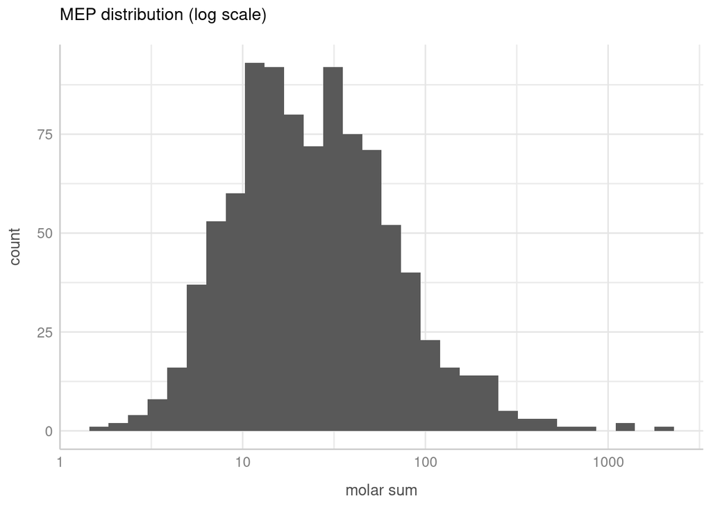

=> MEP looks log noramal(-ish), will include as log in the model

## 2.2 Mean fixation duration

Arithmetic mean of “mean fixation duration” at face recognition and scene exploration tasks:

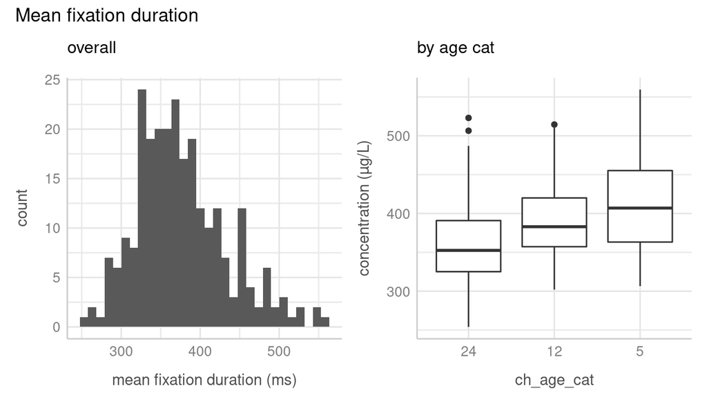

- clear difference with age

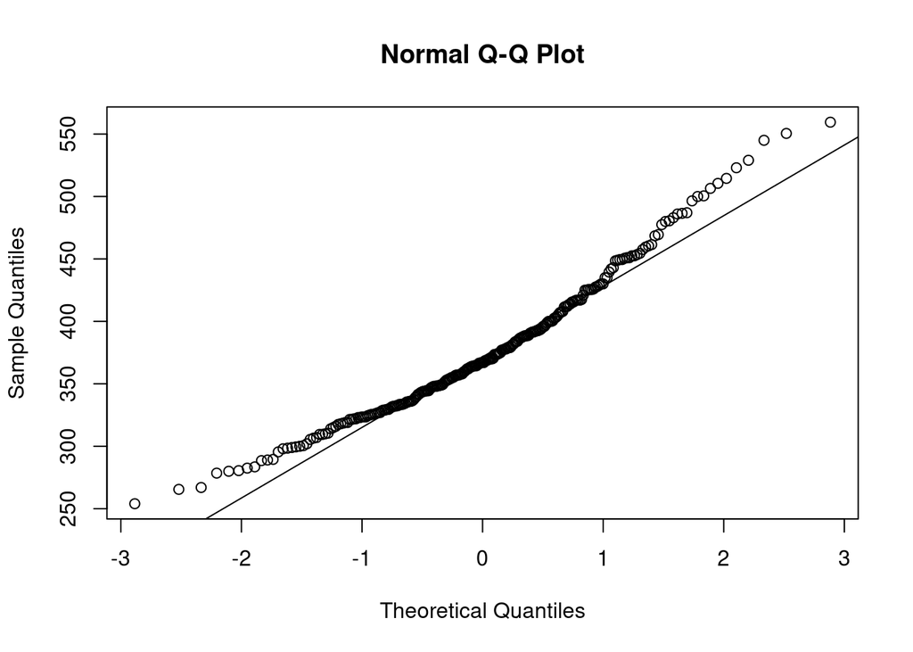

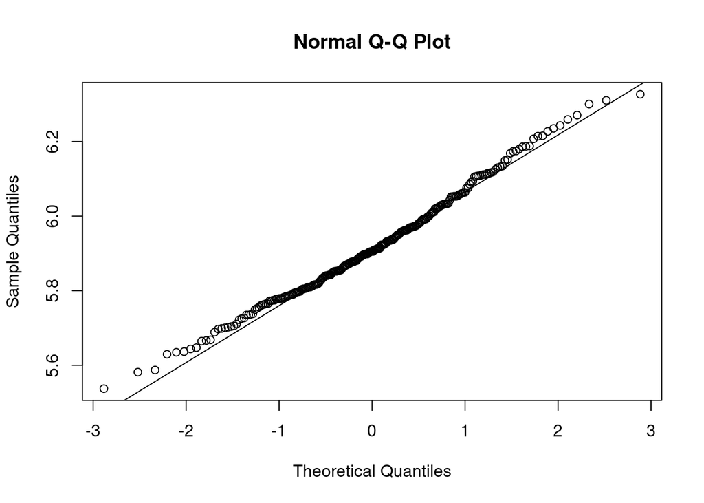

- better log transformed (may want to at least do sensitivity analyses on the log transformed)

## 2.3 Covariates

Selected covariates and coding see `dag_var_coding.html`:

- maternal education
- child sex
- parity
- tobacco
- maternal age

**Missing maternal depression.**

# 3 Model with no exposure

```
##
## Call:
## lm(formula = fix_dur ~ mo_edu + ch_sex + mo_parity + tobacco +
##     mo_age, data = model_data_24)
##
## Residuals:
##     Min      1Q  Median      3Q     Max
## -91.050 -32.820  -8.063  27.517 162.901
##
## Coefficients:
##              Estimate Std. Error t value Pr(>|t|)
## (Intercept)  257.1002    37.4523   6.865 2.25e-10 ***
## mo_edu>Bac+2   7.3016    12.3925   0.589   0.5567
## ch_sex2       -2.3696     8.5596  -0.277   0.7823
## mo_parity1    -0.9676     8.9720  -0.108   0.9143
## mo_parity2     2.8809    17.3067   0.166   0.8680
## tobacco1      34.3557    14.4883   2.371   0.0192 *
## mo_age         2.8545     1.1264   2.534   0.0124 *
## ---
## Signif. codes:  0 '***' 0.001 '**' 0.01 '*' 0.05 '.' 0.1 ' ' 1
##
## Residual standard error: 49.95 on 134 degrees of freedom
##   (10 observations deleted due to missingness)
## Multiple R-squared:  0.08707,    Adjusted R-squared:  0.0462
## F-statistic:  2.13 on 6 and 134 DF,  p-value: 0.05386
```

- effect of tobacco and maternal age
- same results for log transformed fix_dur

# 4 Models with exp

## 4.1 Exposure T2 + T3

Compared models:

Repeated for 24m, 12m and 5m

And mixed effect model:

1. fix_dur ~ MEP_t2 + covariates + age_cat + 1|ident
2. fix_dur ~ MEP_t3 + covariates + age_cat + 1|ident
3. fix_dur ~ MEP_t2_t3 + covariates + age_cat + 1|ident

=> 12 models

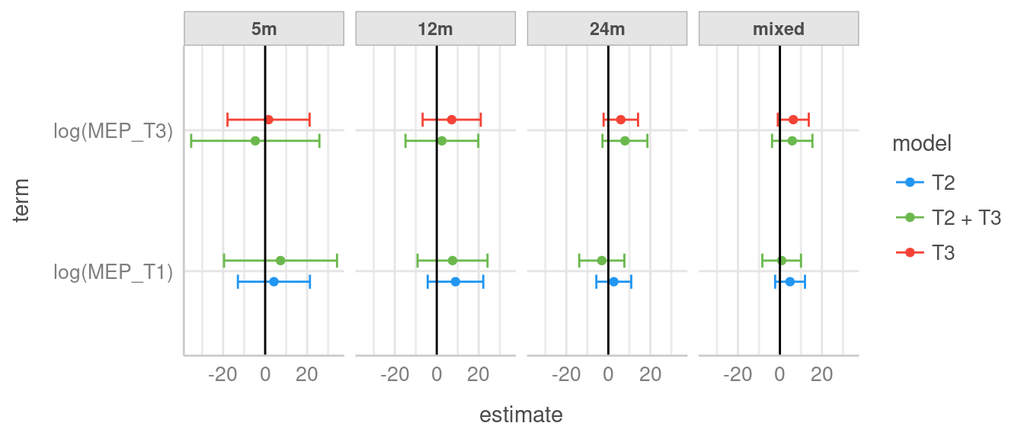

Mixed models with interaction:

- fix_dur ~ log(MEP_T1) * age_cat + covariates + (1|ident)
- fix_dur ~ log(MEP_T3) * age_cat + covariates + (1|ident)
- fix_dur ~ log(MEP_T1) * age_cat + log(MEP_T3) * age_cat + covariates + (1|ident)

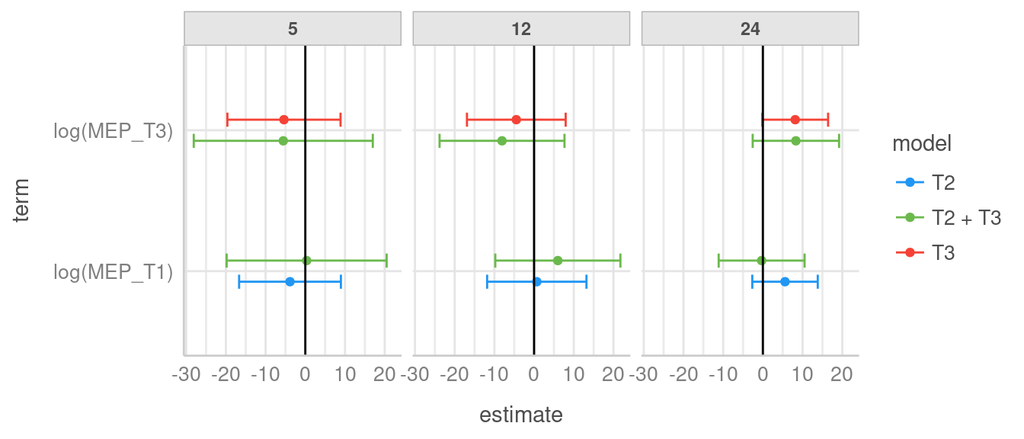

## 4.2 Exposure as long format

# 5 Annex

## 5.1 No exposure model diagnostic

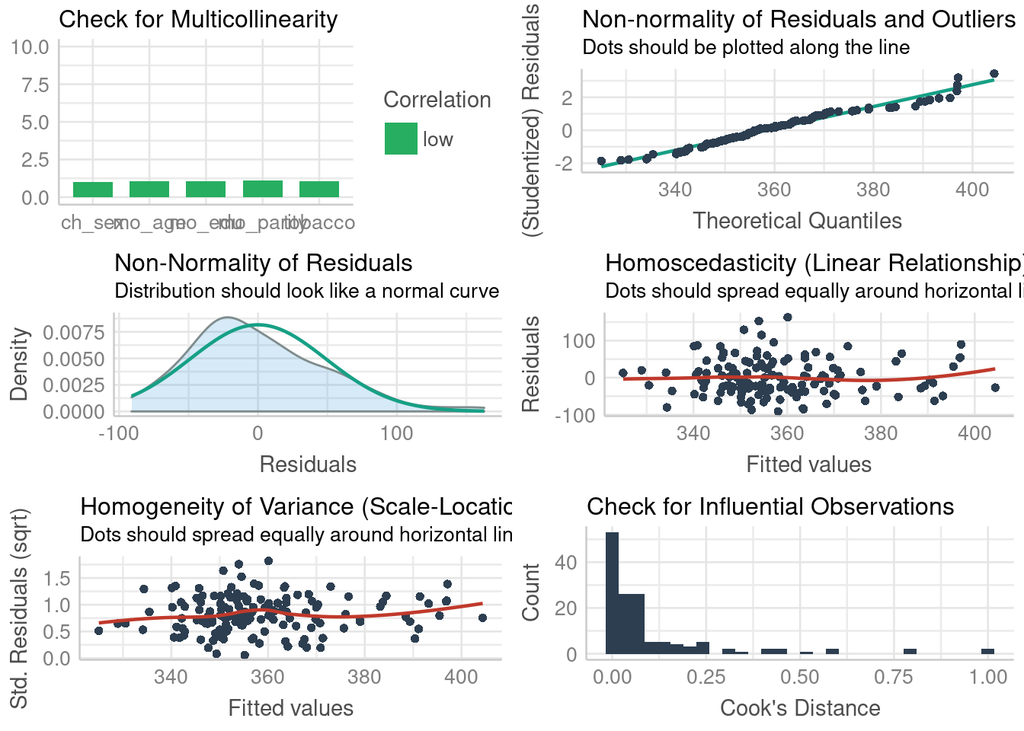

## 5.5 Model values

```
## # A tibble: 16 x 6
##    term        estimate conf.low conf.high model   age
##    <chr>          <dbl>    <dbl>     <dbl> <chr>   <fct>
##  1 log(MEP_T1)    2.60     -5.71     10.9  T2      24m
##  2 log(MEP_T3)    5.95     -2.25     14.2  T3      24m
##  3 log(MEP_T1)   -3.11    -13.9       7.64 T2 + T3 24m
##  4 log(MEP_T3)    7.90     -2.80     18.6  T2 + T3 24m
##  5 log(MEP_T1)    8.93     -4.30     22.2  T2      12m
##  6 log(MEP_T3)    7.12     -6.72     21.0  T3      12m
##  7 log(MEP_T1)    7.53     -9.14     24.2  T2 + T3 12m
##  8 log(MEP_T3)    2.44    -14.9      19.8  T2 + T3 12m
##  9 log(MEP_T1)    4.17    -13.0      21.3  T2      5m
## 10 log(MEP_T3)    1.62    -17.9      21.2  T3      5m
## 11 log(MEP_T1)    7.32    -19.6      34.2  T2 + T3 5m
## 12 log(MEP_T3)   -4.71    -35.3      25.8  T2 + T3 5m
## 13 log(MEP_T1)    4.82     -2.29     11.9  T2      mixed
## 14 log(MEP_T3)    6.37     -1.01     13.7  T3      mixed
## 15 log(MEP_T1)    0.818    -8.40     10.0  T2 + T3 mixed
## 16 log(MEP_T3)    5.87     -3.75     15.5  T2 + T3 mixed
```